# Introduction

To begin with, the states on the z-axis are given by Equation (5.14).

$$\begin{equation}
X∣0⟩ = \begin{bmatrix}
0 & 1 \\
1 & 0 \\
\end{bmatrix} \begin{bmatrix}
1 \\
0 \\
\end{bmatrix} = \begin{bmatrix}
0 \\
1 \\
\end{bmatrix} = ∣1⟩ \\
X∣1⟩ = \begin{bmatrix}
0 & 1 \\
1 & 0 \\
\end{bmatrix} \begin{bmatrix}
0 \\
1 \\
\end{bmatrix} = -\begin{bmatrix}
1 \\
0 \\
\end{bmatrix} = ∣0⟩ \\
Y∣0⟩ = \begin{bmatrix}
0 & i \\
-i & 0 \\
\end{bmatrix} \begin{bmatrix}
1 \\
0 \\
\end{bmatrix} = \begin{bmatrix}
0 \\
-i \\
\end{bmatrix} = -i∣1⟩ \\
Y∣1⟩ = \begin{bmatrix}
0 & i \\
-i & 0 \\
\end{bmatrix} \begin{bmatrix}
0 \\
1 \\
\end{bmatrix} = \begin{bmatrix}
i \\
0 \\
\end{bmatrix} =i∣0⟩ \\
Z∣0⟩ = \begin{bmatrix}
1 & 0 \\
0 & -1 \\
\end{bmatrix} \begin{bmatrix}
1 \\
0 \\
\end{bmatrix} = \begin{bmatrix}
1 \\
0 \\
\end{bmatrix} = ∣0⟩ \\
Z∣1⟩ = \begin{bmatrix}
1 & 0 \\
0 & -1 \\
\end{bmatrix} \begin{bmatrix}
0 \\
1 \\
\end{bmatrix} = -\begin{bmatrix}
0 \\
1 \\
\end{bmatrix} = -∣1⟩ \\
\tag{5.14}
\end{equation}$$

```r
X(1)*six_state(1)[[1]]
```

```
##    ( 1 ) * |1>
```

```r
X(1)*six_state(2)[[1]]
```

```
##    ( 1 ) * |0>
```

```r
Y(1)*six_state(1)[[1]]
```

```
##    ( 0-1i )  * |1>
```

```r
Y(1)*six_state(2)[[1]]
```

```
##    ( 0+1i )  * |0>
```

```r
Z(1)*six_state(1)[[1]]
```

```
##    ( 1 ) * |0>
```

```r
Z(1)*six_state(2)[[1]]
```

```
##    ( -1 )    * |1>
```

So, the coordinates of states $∣0⟩$ and $∣1⟩$ in z-axis are given by Equation (5.15)

$$\begin{equation}
<0|X|0> = <0|1> = 0 \\
<0|Y|0> = <0|i|1> = i<0|1> = 0 \\
<0|Z|0> = <0|0> = 1 \\
\therefore (x,y,z) = (0,0,1) \\
<1|X|1> = <1|0> = 0 \\
<1|Y|1> = <1|(-i)|0> = -i<1|0> = 0 \\
<1|Z|1> = <1|(-1)|1> = -<1|> = -1 \\
\therefore (x,y,z) = (0,0,-1)
\tag{5.15}
\end{equation}$$

```r
bra0 %*% (X(1)*six_state(1)[[1]])@coefs
```

```
##      [,1]
## [1,] 0+0i
```

```r
bra0 %*% (Y(1)*six_state(1)[[1]])@coefs
```

```
##      [,1]
## [1,] 0+0i
```

```r
bra0 %*% (Z(1)*six_state(1)[[1]])@coefs
```

```
##      [,1]
## [1,] 1+0i
```

```r
bra1 %*% (X(1)*six_state(2)[[1]])@coefs
```

```
##      [,1]
## [1,] 0+0i
```

```r
bra1 %*% (Y(1)*six_state(2)[[1]])@coefs
```

```
##      [,1]
## [1,] 0+0i
```

```r
bra1 %*% (Z(1)*six_state(2)[[1]])@coefs
```

```
##       [,1]
## [1,] -1+0i
```

Analogously, the states on the x-axis are given by Equation (5.16).

$$\begin{equation}
X∣+⟩ = \begin{bmatrix}
0 & 1 \\
1 & 0 \\
\end{bmatrix} \Big(\frac{1}{\sqrt{2}}\Big) \begin{bmatrix}
1 \\
1 \\
\end{bmatrix} = \frac{1}{\sqrt{2}} \begin{bmatrix}
1 \\
1 \\
\end{bmatrix} = ∣+⟩ \\
X∣-⟩ = \begin{bmatrix}
0 & 1 \\
1 & 0 \\
\end{bmatrix} \Big(\frac{1}{\sqrt{2}}\Big) \begin{bmatrix}
1 \\
-1 \\
\end{bmatrix} = \frac{1}{\sqrt{2}} \begin{bmatrix}
-1 \\
1 \\
\end{bmatrix} = -∣-⟩ \\
Y∣+⟩ = \begin{bmatrix}
0 & i \\
-i & 0 \\
\end{bmatrix} \Big(\frac{1}{\sqrt{2}}\Big) \begin{bmatrix}
1 \\
1 \\
\end{bmatrix} = \frac{1}{\sqrt{2}} \begin{bmatrix}
i \\
-i \\
\end{bmatrix} = i∣-⟩ \\
Y∣-⟩ = \begin{bmatrix}
0 & i \\
-i & 0 \\
\end{bmatrix} \Big(\frac{1}{\sqrt{2}}\Big) \begin{bmatrix}
1 \\
-1 \\
\end{bmatrix} = \frac{1}{\sqrt{2}} \begin{bmatrix}
-i \\
-i \\
\end{bmatrix} = -i∣+⟩ \\
Z∣+⟩ = \begin{bmatrix}
1 & 0 \\
0 & -1 \\
\end{bmatrix} \Big(\frac{1}{\sqrt{2}}\Big) \begin{bmatrix}
1 \\
1 \\
\end{bmatrix} = \frac{1}{\sqrt{2}} \begin{bmatrix}
1 \\
-1 \\
\end{bmatrix} = ∣-⟩ \\
Z∣-⟩ = \begin{bmatrix}
1 & 0 \\
0 & -1 \\
\end{bmatrix} \Big(\frac{1}{\sqrt{2}}\Big) \begin{bmatrix}
1 \\
-1 \\
\end{bmatrix} = \frac{1}{\sqrt{2}} \begin{bmatrix}
1 \\
1 \\
\end{bmatrix} = ∣+⟩ \\
\tag{5.16}
\end{equation}$$

```r
X(1)*six_state(3)[[1]]
```

```
##    ( 0.7071068 ) * |0>
##  + ( 0.7071068 ) * |1>
```

```r
X(1)*six_state(4)[[1]]
```

```
##    ( -0.7071068 )    * |0>
##  + ( 0.7071068 ) * |1>
```

```r
Y(1)*six_state(3)[[1]]
```

```
##    ( 0+0.7071068i )  * |0>
##  + ( 0-0.7071068i )  * |1>
```

```r
Y(1)*six_state(4)[[1]]
```

```
##    ( 0-0.7071068i )  * |0>
##  + ( 0-0.7071068i )  * |1>
```

```r
Z(1)*six_state(3)[[1]]
```

```
##    ( 0.7071068 ) * |0>
##  + ( -0.7071068 )    * |1>
```

```r
Z(1)*six_state(4)[[1]]
```

```
##    ( 0.7071068 ) * |0>
##  + ( 0.7071068 ) * |1>
```

And the coordinates of states $∣+⟩$ and $∣-⟩$ in x-axis are given by Equation (5.17).

```r
brax_plus %*% (X(1)*six_state(3)[[1]])@coefs
```

```
##      [,1]
## [1,] 1+0i
```

```r
brax_plus %*% (Y(1)*six_state(3)[[1]])@coefs
```

```
##      [,1]
## [1,] 0+0i
```

```r
brax_plus %*% (Z(1)*six_state(3)[[1]])@coefs
```

```
##      [,1]
## [1,] 0+0i
```

```r
brax_minus %*% (X(1)*six_state(4)[[1]])@coefs
```

```
##       [,1]
## [1,] -1+0i
```

```r
brax_minus %*% (Y(1)*six_state(4)[[1]])@coefs
```

```
##      [,1]
## [1,] 0+0i
```

```r
brax_minus %*% (Z(1)*six_state(4)[[1]])@coefs
```

```
##      [,1]
## [1,] 0+0i
```

For the states on the y-axis, the same procedure follows and they are given in Equation (5.18).

$$\begin{equation}
X∣i⟩ = \begin{bmatrix}
0 & 1 \\
1 & 0 \\
\end{bmatrix} \Big(\frac{1}{\sqrt{2}}\Big) \begin{bmatrix}
1 \\
i \\
\end{bmatrix} = \frac{1}{\sqrt{2}} \begin{bmatrix}
i \\
1 \\
\end{bmatrix} = i\Bigg(\frac{1}{\sqrt{2}}\Bigg) \begin{bmatrix}
1 \\
-i \\
\end{bmatrix} = i∣-i⟩ \\
X∣-i⟩ = \begin{bmatrix}
0 & 1 \\
1 & 0 \\
\end{bmatrix} \Big(\frac{1}{\sqrt{2}}\Big) \begin{bmatrix}
1 \\
-i \\
\end{bmatrix} = \frac{1}{\sqrt{2}} \begin{bmatrix}
-i \\
1 \\
\end{bmatrix} = -i \Bigg(\frac{1}{\sqrt{2}}\Bigg) \begin{bmatrix}
1 \\
i \\
\end{bmatrix} = -i∣i⟩ \\
Y∣i⟩ = \begin{bmatrix}
0 & i \\
-i & 0 \\
\end{bmatrix} \Big(\frac{1}{\sqrt{2}}\Big) \begin{bmatrix}
1 \\
i \\
\end{bmatrix} = \frac{1}{\sqrt{2}} \begin{bmatrix}
i² \\
- i \\
\end{bmatrix} = -\frac{1}{\sqrt{2}} \begin{bmatrix}
1 \\
i \\
\end{bmatrix} = -∣i⟩ \\
Y∣-i⟩ = \begin{bmatrix}
0 & i \\
-i & 0 \\
\end{bmatrix} \Big(\frac{1}{\sqrt{2}}\Big) \begin{bmatrix}
1 \\
-i \\
\end{bmatrix} = \frac{1}{\sqrt{2}} \begin{bmatrix}
-i² \\
-i \\
\end{bmatrix} = \frac{1}{\sqrt{2}} \begin{bmatrix}
1 \\
-i \\
\end{bmatrix} = ∣-i⟩ \\
Z∣i⟩ = \begin{bmatrix}
1 & 0 \\
0 & -1 \\
\end{bmatrix} \Big(\frac{1}{\sqrt{2}}\Big) \begin{bmatrix}
1 \\
i \\
\end{bmatrix} = \frac{1}{\sqrt{2}} \begin{bmatrix}
1 \\
-i \\
\end{bmatrix} = ∣-i⟩ \\
Z∣-i⟩ = \begin{bmatrix}
1 & 0 \\
0 & -1 \\
\end{bmatrix} \Big(\frac{1}{\sqrt{2}}\Big) \begin{bmatrix}
1 \\
-i \\
\end{bmatrix} = \frac{1}{\sqrt{2}} \begin{bmatrix}
1 \\
i \\
\end{bmatrix} = ∣i⟩ \\
\tag{5.18}
\end{equation}$$

```r
X(1)*six_state(5)[[1]]
```

```
##    ( 0+0.7071068i )  * |0>
##  + ( 0.7071068+0i )  * |1>
```

```r
X(1)*six_state(6)[[1]]
```

```
##    ( 0-0.7071068i )  * |0>
##  + ( 0.7071068+0i )  * |1>
```

```r
Y(1)*six_state(5)[[1]]
```

```
##    ( -0.7071068+0i ) * |0>
##  + ( 0-0.7071068i )  * |1>
```

```r
Y(1)*six_state(6)[[1]]
```

```
##    ( 0.7071068+0i )  * |0>
##  + ( 0-0.7071068i )  * |1>
```

```r
Z(1)*six_state(5)[[1]]
```

```
##    ( 0.7071068+0i )  * |0>
##  + ( 0-0.7071068i )  * |1>
```

```r
Z(1)*six_state(6)[[1]]
```

```
##    ( 0.7071068+0i )  * |0>
##  + ( 0+0.7071068i )  * |1>
```

Finally, the coordinates of states $∣i⟩$ and $∣-i⟩$ in y-axis are given by Equation (5.19).

$$\begin{equation}
<i|X|i> = <i|(i)|-i> = i<i|-i> = i(0) = 0 \\
<i|Y|i> = -<i|i> = -1 \\
<i|Z|i> = <i|-i> = 0 \\
\therefore (x,y,z) = (0,-1,0) \\
<-i|X|-i> = <-i|(-i)|i> = -i<-i|i> = 0 \\
<-i|Y|-i> = <-i|-i> = 1 \\
<-i|Z|-i> = <-i|i> = 0 \\
\therefore (x,y,z) = (0,1,0)
\tag{5.19}
\end{equation}$$

```r
bray_iplus %*% (X(1)*six_state(5)[[1]])@coefs
```

```
##      [,1]
## [1,] 0+0i
```

```r
bray_iplus %*% (Y(1)*six_state(5)[[1]])@coefs
```

```
##       [,1]
## [1,] -1+0i
```

```r
bray_iplus %*% (Z(1)*six_state(5)[[1]])@coefs
```

```
##      [,1]
## [1,] 0+0i
```

```r
bray_iminus %*% (X(1)*six_state(6)[[1]])@coefs
```

```
##      [,1]
## [1,] 0+0i
```

```r
bray_iminus %*% (Y(1)*six_state(6)[[1]])@coefs
```

```
##      [,1]
## [1,] 1+0i
```

```r
bray_iminus %*% (Z(1)*six_state(6)[[1]])@coefs
```

```
##      [,1]
## [1,] 0+0i
```

Using the `pure_qubit1` function with the `spherical` argument set to `TRUE`, a normalized pure quantum state gets represented as a point r in the Bloch sphere.

```r
# Define |0>
theta <- 0
phi <- 0

# Create the point on +z-axis in Bloch sphere
pure_qubit1(theta, phi, spherical = TRUE)
```

```
## x y z
## 0 0 1
```

# 6 Quantum Gates

Quantum gates are fundamental components of quantum computing, enabling the manipulation and transformation of qubits, the building blocks of quantum information. Here’s a structured section on quantum gates that integrates both theoretical explanations and practical implementation using `qsimulatR`.

## 6.1 Introduction to Quantum Gates

Quantum gates are unitary transformations that act on qubits, changing their states and enabling quantum computations. They play a crucial role in quantum algorithms and are based on linear quantum operators represented by unitary matrices.

## 6.2 Properties of Quantum Gates

- Unitary Transformations: Quantum gates are represented by unitary matrices, ensuring reversibility and preservation of quantum information.
- Linearity: They follow linear operations, essential for quantum superposition and entanglement phenomena.
- Gate Combinations: Combining quantum gates allows for the creation of complex quantum algorithms.

## 6.3 Pauli Gates

### 6.3.1 Pauli-X Gate (Bit Flip):

The Pauli-X gate corresponds to a classical NOT operation, flipping the computational basis states $|0⟩$ and $|1⟩$. Its matrix representation is a Pauli-X matrix.

```r
X(1)@M
```

```
##      [,1] [,2]
## [1,] 0+0i 1+0i
## [2,] 1+0i 0+0i
```

The action of the X gate is visualized using the `plot` function:

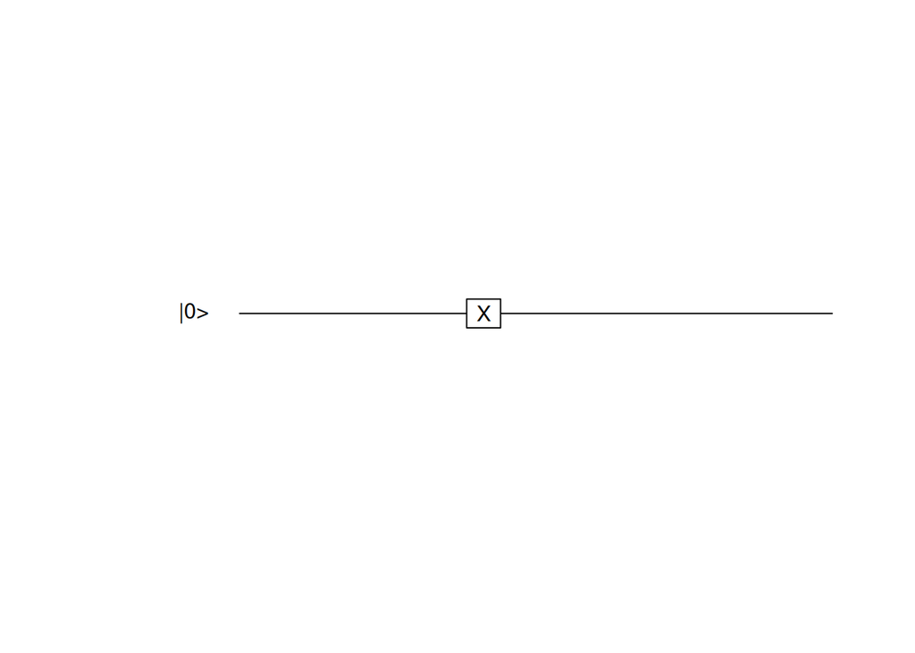

```r
(X(1)*six_state(1)[[1]]) |> plot(qubitnames = "|0>")
```

### 6.3.2 Pauli-Y Gate (Bit & Phase Flip):

The Pauli-Y gate combines a bit flip and a phase flip, interchanging $|0⟩$ and $|1⟩$ and applying a relative phase. Its matrix representation:

```r
Y(1)@M
```

```
##      [,1] [,2]
## [1,] 0+0i 0+1i
## [2,] 0-1i 0+0i
```

For visualization:

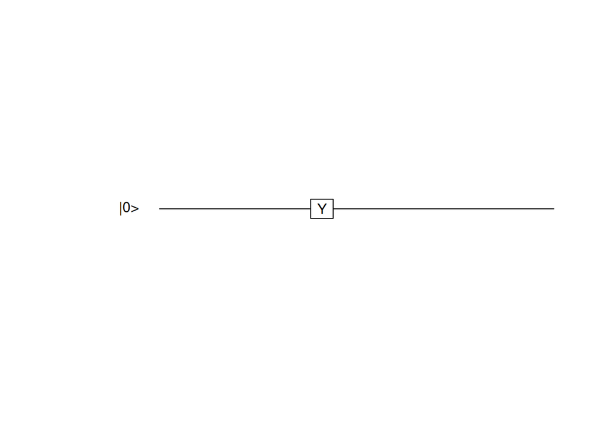

```r
(Y(1)*six_state(1)[[1]]) |> plot(qubitnames = "|0>")
```

### 6.3.3 Pauli-Z Gate (Phase Flip):

The Pauli-Z gate flips the phase of the $|1⟩$ state relative to $|0⟩$ in the computational basis. Matrix representation:

```r
Z(1)@M
```

```
##      [,1]  [,2]
## [1,] 1+0i  0+0i
## [2,] 0+0i -1+0i
```

Plotting the action of the Z gate gives:

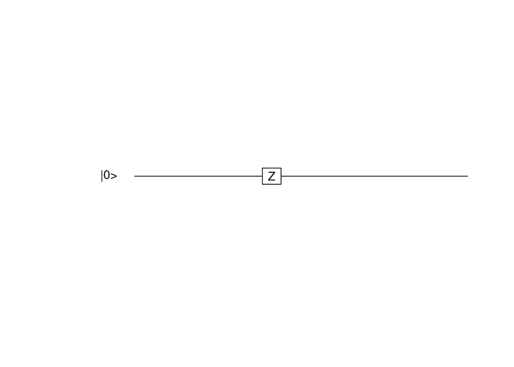

```r
(Z(1)*six_state(1)[[1]]) |> plot(qubitnames = "|0>")
```

### 6.3.4 Hadamard Gate

The Hadamard gate creates a uniform superposition, crucial for quantum algorithm initialization. Its matrix representation:

```r
H(1)@M
```

```
##              [,1]          [,2]
## [1,] 0.7071068+0i  0.7071068+0i
## [2,] 0.7071068+0i -0.7071068+0i
```

Visualization of the action of the Hadamard gate is inherited from the `plot` method:

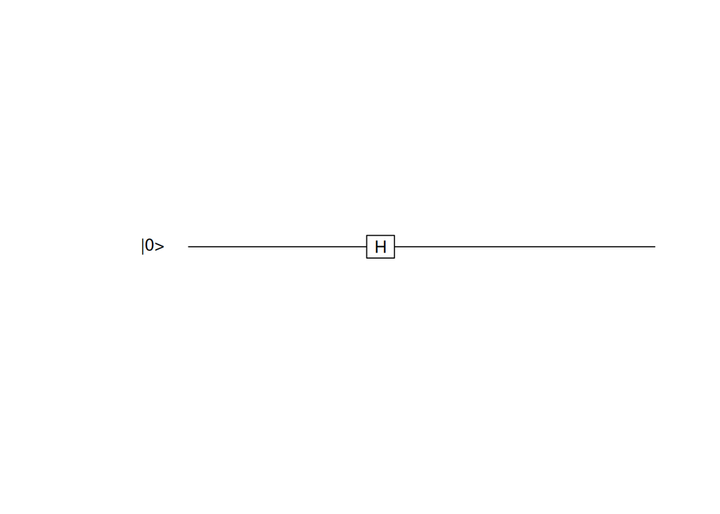

```r
# H.|0>
(H(1)*six_state(1)[[1]]) |> plot(qubitnames = "|0>")
```

### 6.3.5 Other Quantum Gates

- S Gate (Phase Gate Z90): Adds a $90°$ rotation to the phase, useful in phase manipulation.
- T Gate (Phase Gate): Performs a quarter of the Z gate and a half of the S gate, providing additional phase control.

Visualization of the action of the S gate using the plot function:

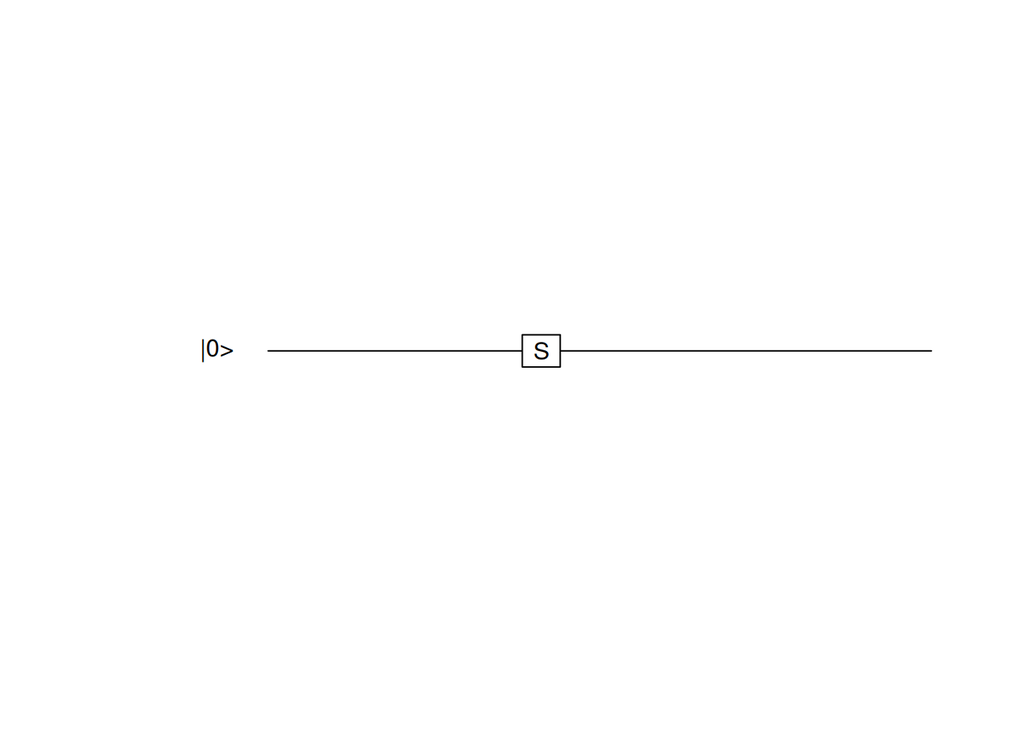

```r
(S(1)*six_state(1)[[1]]) |> plot(qubitnames = "|0>")
```

The T gate performs a quarter of the Z gate and a half of the S gate.

## 6.4 Implementation with qsimulatR and qvirus

Using `qsimulatR` and `qvirus`, one can create, visualize, and analyze quantum gates and circuits. For example:

- Creating a Hadamard gate: `H(1)`
- Applying a gate to a quantum state: `H(1)*six_state(1)[[1]]`
- Visualization: `(H(1)*six_state(1)[[1]]) |> plot(qubitnames = "|0>")`

## 6.5 Conclusion

Quantum gates are foundational to quantum computing, enabling the execution of quantum algorithms and the manipulation of quantum information.

Ostmeyer, Johann, and Carsten Urbach. 2023. *qsimulatR: A Quantum Computer Simulator*. https://CRAN.R-project.org/package=qsimulatR.